# 1. Pandas 란 - 데이터 처리를 위한 라이브러리

- Wes MaKinney (월스트리트 금융분석 전문가)가 개발
- 핵심내용은 2차원 (행X열) 데이터를 핸들링 하여 효율적으로 가공/분석
- 1) Series - column이 하나
- 2) DataFrame - column이 여러개, Series의 집합체, 2차원 (행X열) 데이터를 담은 데이터 구조체
- 리스트, 컬렉션, 넘파이 등의 파이썬 내부 데이터뿐만 아니라 CSV 등의 파일을 쉽게 DataFrame으로 변경하여 가공/분석을 편리하게 수행

## 1. 라이브러리 불러오기

```python
#아나콘다에서 설치
#!pip install pandas
```

```python
import pandas as pd
```

# 2. Pandas 의 데이터 타입

## 1) Series

- Series 는 1차원 배열로 배열의 각 값(values)에 대응되는 인덱스(index)를 부여할 수 있는 구조
- 즉 인덱스(index)와 값이 쌍으로 존재하는 구조 - sr.index, sr.values
- 생성시에는 index=, data= 으로 설정!

```python
sr = pd.Series(data=[17000, 18000, 1000, 5000])
```

```python
sr
```

- index를 설정하지 않았으므로 임의의 값인 0,1,2,3으로 나옴

```python
sr = pd.Series(index=[17000, 18000, 1900, 2000],
               data=["피자", "치킨","콜라", "맥주"])
```

```python
print(sr)
```

- 'data='은 생략가능

```python
sr = pd.Series([17000, 18000, 1000, 5000])
```

```python
sr = pd.Series([17000, 18000, 1000, 5000],
               index=["피자", "치킨", "콜라", "맥주"])
```

```python
sr.index
```

## 2) Dataframe

- 행과 열을 가지는 2차원 자료구조
- 행방향 인덱스(index)와 열방향 인덱스(column)가 존재
- 시리즈와 데이터프리임의 구조를 비교하면
  - 시리즈: 인덱스(index)와 값(values)으로 구성 (생성시에는 index=, data= 으로 설정!)
  - 데이터프레임: 인덱스(index), 열(columns) 값(values)으로 구성(생성시에는 index=, columns=, data= 으로 설정!)

```python
index = ['one', 'two', 'three']
```

```python
columns = ['A', 'B', 'C']
```

```python
values = [[1, 2, 3], [4, 5, 6], [7, 8, 9]]
```

```python
df = pd.DataFrame(data=values, index=index, columns=columns)
```

```python
df
```

- 생성된 데이터프레임으로부터 인덱스(index), 열(columns), 값(values)을 각각 출력해 보면..

```python
df.index
```

```python
df.columns
```

```python
df.values
```

# 3. DataFrame 의 생성

- DataFrame은 리스트(List), 시리즈(Series), 딕셔너리(dict), Numpy의 ndarrays, 또 다른 데이터프레임으로부터 생성할 수 있음
- pd.DataFrame()

## 1) 리스트를 이용한 데이터프레임 생성

- value만 먼저 설정

```python
data_sets = [
    ['1000', 'Steve', 90.72],  #-->1행
    ['1001', 'James', 78.09]   #-->2행
]
```

```python
pd.DataFrame(data=data_sets)
```

- 생성된 데이터프레임에 열(columns)을 지정

```python
pd.DataFrame(data=data_sets, columns=['학번', '이름', '점수'])
```

- index 지정

```python
pd.DataFrame(data=data_sets, columns=['학번', '이름', '점수'],
                  index=['first', 'second'])
```

## 2) 딕셔너리로부터 데이터프레임 생성 - {'key' : [value]}

```python
data = {
    '학번' : ['1000', '1001'],
    '이름' : [ 'Steve', 'James'],
    '점수': [90.72, 78.09]
    }
```

```python
pd.DataFrame(data)
```

## 3) 외부 파일로 부터 데이터프레임 생성

- Pandas는 CSV, 텍스트, Excel, SQL, HTML, JSON 등 다양한 데이터 파일을 읽어 데이터 프레임을 생성할 수 있음
- pd.read_csv()

```python
# 파일 로딩
lemonade = pd.read_csv('lemonade.csv')
```

```python
lemonade.info()
```

- lemonade: pd.read_csv()로 로드하였으므로 데이터프레임 구조임

```python
lemonade
```

이 경우 인덱스는 자동으로 부여됨

```python
print(lemonade.index)
```

# 4. DataFrame 조회하기

```python
lemonade.head(3)
```

```python
lemonade.tail(3)
```

- 기술통계 - 단, object타입인 Date와 Location은 기술통계 결과에서 제외됨

```python
lemonade.describe()
```

- Location을 구성하고 있는 value를 count해 보면..

```python
lemonade['Location'].value_counts()
```

# 5. 데이터 다뤄보기

## 1) 열(column) 추가하기

```python
lemonade['Sold'] = 0
```

```python
lemonade.head(3)
```

```python
lemonade['Sold'] = lemonade['Lemon'] + lemonade['Orange']
```

```python
lemonade.head(3)
```

```python
lemonade['Revenue'] = lemonade['Price'] * lemonade['Sold']
```

```python
lemonade.head(3)
```

## 2) 열(column) 제거하기

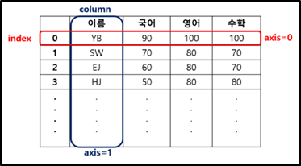

- **drop(열이름, axis=1(열방향이란 뜻))**

```python
lemonade.drop(['Sold'], axis=1)
```

```python
lemonade
```

```python
lemonade.drop(['Date','Location'], axis=1)
```

```python
lemonade
```

- **drop(행번호(=index값), axis=0(행방향이란 뜻)))**

```python
lemonade.drop(0, axis=0)
```

```python
lemonade
```

### lemonade 자체에서 행과 열이 drop된 것은 아님. 그럴려면..

- **lemonade = lemonade.drop()** 혹은
- **inplace=True** 옵션을 써야함!

```python
lemonade.head(3)
```

```python
lemonade.drop(['Orange'], axis=1, inplace=True)
```

```python
lemonade
```

# 6. 데이터 인덱싱

## 1) 특정 행만 조회 - selection연산자

- 0~4행을 indexing해 보자

```python
lemonade[0:5]
```

## 2) 특정 열만 조회

- 두 열만 조회해 보자(이중 괄호임에 주의!)

```python
# 두 열만 조회
lemonade[['Date', 'Location']]
```

## 3) iloc - index로 원하는 location 조회

- **0-m행, 0-n열을 찾고 싶으면**
- **iloc[0:m+1, 0:n+1]로 설정**
- **아래 예제는 0-2행, 0-1열을 indexing**

```python
lemonade.iloc[0:3, 0:2]
```

```python
lemonade.iloc[1:3]  #1,2행 (열에 대해서는 특정하지 않았으므로 모두 출력)
```

```python
lemonade.iloc[[1]]    #1행만
```

## 4) loc - 컬럼 이름으로 (원하는 인덱스의) location 조회

- **[0-m행, Date와 Location열을 원한다면]**
- **[0:m, ['Date', 'Location']]**
- iloc과 행번호가 차이남을 확인!

```python
lemonade.loc[0:2, ['Date','Location']]
```

```python
# column도 index로 나타낼 수 있을까?
#lemonade.loc[0:2, 0:2]
```

## 5) 조건 인덱싱

```python
#조건에 해당되는 행만 출력
lemonade['Location'] == 'Beach'
```

- **만약 조건을 만족하는 lemonade의 행을 모두 출력하게 하려면?**
- **lemonade[조건]**

```python
lemonade[lemonade['Location'] == 'Beach']
```

```python
# 조건이 하나일 때, 모든 열 출력
lemonade.loc[lemonade['Revenue']>45]
```

```python
# 조건이 하나일 때, 일부 열만 출력
lemonade.loc[lemonade['Revenue']>45, ['Date','Revenue']]
```

```python
# & (and) 조건일 때
lemonade.loc[ (lemonade['Revenue']>45) & (lemonade['Revenue']<100), ['Date', 'Revenue']]
```

```python
# | (or) 조건일 때
lemonade.loc[ (lemonade['Revenue']<45) | (lemonade['Revenue']>100), ['Date', 'Revenue']]
```

# 7. 행을 추가해 보자!

```python
lemonade2=lemonade[0:2]
lemonade2
```

```python
lemonade3=lemonade.append(lemonade2)
lemonade3
```

```python
#총 34개행, 0~33 (추가된 2개 포함)
lemonade3[0:34]
```

# 8. 데이터 전처리 몇가지 - 정렬, 그룹핑, 결측값처리

## 1) sort_values() - 데이터 정렬

```python
lemonade.sort_values(by=['Temperature'])
```

- **inplace = True --> 정렬한 값이 lemonade에 바로 저장**
- **inplace = True 없이 실행한 경우 1회성으로 결과만 보여줄뿐 lemonade의 실제 내용은 바뀌지 않음**

```python
lemonade
```

```python
lemonade.sort_values(by=['Temperature'], inplace = True)
```

```python
lemonade
```

- 내림차순으로 하고 싶다면? ascending= False

```python
lemonade.sort_values(by=['Temperature'], ascending= False, inplace = True)
```

```python
lemonade
```

```python
lemonade.sort_values(by=['Temperature'], ascending= False)
```

### 만약 Temperature로는 내림차순 정렬, 다시 Revenue로는 오름차순 정렬을 하고 싶다면?

```python
lemonade.sort_values(by=['Temperature', 'Revenue'], ascending=[False, True])
```

## 2) groupby() - 데이터 그룹핑

```python
lemonade.groupby(by='Location')   # lemonade.groupby(by=['Location'])
```

```python
lemonade.groupby(by='Location').count()
```

- location별 그룹핑 하여 Revenue값의 max와 min을 보고싶다면?

```python
lemonade.groupby(by='Location')['Revenue'].max()
```

```python
lemonade.groupby(by='Location')['Revenue'].min()
```

## 3) 결측 데이터 처리하기

### isna()- 결측데이터 여부 확인

```python
lemonade.isna().tail(20)
```

```python
lemonade.isna( ).head(10)
```

```python
lemonade.isna( ).sum( )
```

### fillna( ) - Missing 데이터 대체하기

```python
# 주의! 아래처럼하면 어떻게 될까?
lemonade['Leaflets'].fillna(0)
```

```python
lemonade.tail(20)
```

```python
lemonade['Leaflets'] = lemonade['Leaflets'].fillna(0)
```

```python
lemonade.tail(20)
```